# Simulation for checking statistical procedures and model fits

Presented by AG Schissler

Wednesday November 20, 2019

## I. Opening

### Start-of-class work

1. Please log in the your workstation.
2. Open the RStudio application on your machine.
3. Open 24_model_checking_fake_data.Rmd from website so that you can work along the lecture.
4. Open [lab_09_models.Rmd](https://github.com/grizant/STAT445/blob/master/labs/lab_08_monte_carlo.Rmd) to have the lab available.

### This week’s agenda

- This week begins the third and final unit of the course: Statistical Inference through Computing.
- You are reviewing probability in a DataCamp module.

## I. Opening (5-10 minutes)

Today I’ll introduce the concept of using simulation to check code and statistical procedures — and to assess how well a model fits the data. `R` has some great features to conduct these studies. Why simulate? Welcome to the 21st century! Two reasons:  
1) Often, simulations can be easier than hand calculations.  
2) Often, simulations can be made more realistic than hand calculations.

### Fake-data simulation

- Checking code and statistical procedure entails using simulation strategies to produce synthetic data (aka *fake data* or *frauda*) then fit a model to these data.
- The results should roughly align with the specified (true) values. This gives you confidence that the computer program is working.
- The results should align with expected (theoretical) results. This can assess whether the model is performing as advertised. For example, what are the empricial coverage rates?

### Predictive simulations

- I’ll describe the use of *predictive simulations* to check how well a model fits data.
- This invovles fitting a statistical model to real data (as opposed to fitting a model to fake data, as above).
- Then repeated simulations are conducted using the model and covariates to generate predicted responses.
- These replicated data sets are then compared visually and more formally (numerically) to the original data.

### Learning outcomes

- Students will recall simulation strategies for checking statistical procedures and model fits.
- Students will apply simulation strategies for checking statistical procedures and model fits.

### Notes

Most of this lecture is derived from Chapters 7 and 8 from the outstanding textbook *Data Analysis Using Regression and Multilevel/Hierachical Models* by Gelman and Hill 2007. We’ll proceed through a series of examples of increasing complex models with code provided in `R`. The useful `R` package `arm` will do must of the heavy lifting (coding) for us.

## II. Fake-data simulation (15 - 30 min)

The key concept in fake-data simulation for model checking is to **simulate from a statistical model known parameter values/functional form and check the properties of the procedure against theory**.

### Example 1: Simple linear regression (SLS) with Gaussian errors

```r
## Fake-data simulation
library("arm")
a <- 1.4
b <- 2.3
sigma <- 0.9
x <- 1:5
n <- length(x)

# Simulate data, fit the model, and check the coverage of the conf intervals

y <- a + b*x + rnorm (n, 0, sigma)
lm.1 <- lm (y ~ x)
display (lm.1)
```

```
## lm(formula = y ~ x)
##             coef.est coef.se
## (Intercept) 2.00     0.74
## x           2.23     0.22
## ---
## n = 5, k = 2
## residual sd = 0.71, R-Squared = 0.97
```

```r
b.hat <- coef (lm.1)[2]       # "b" is the 2nd coef in the model
b.se <- se.coef (lm.1)[2]     # "b" is the 2nd coef in the model

cover.68 <- abs (b - b.hat) < b.se     # this will be TRUE or FALSE
cover.95 <- abs (b - b.hat) < 2*b.se   # this will be TRUE or FALSE
cat (paste ("68% coverage: ", cover.68, "\n"))
```

```
## 68% coverage:  TRUE
```

```r
cat (paste ("95% coverage: ", cover.95, "\n"))
```

```
## 95% coverage:  TRUE
```

```r
# Put it in a loop

n.fake <- 1000
cover.68 <- rep (NA, n.fake)
cover.95 <- rep (NA, n.fake)
for (s in 1:n.fake){
  y <- a + b*x + rnorm (n, 0, sigma)
  lm.1 <- lm (y ~ x)
  b.hat <- coef (lm.1)[2]
  b.se <- se.coef (lm.1)[2]
  cover.68[s] <- abs (b - b.hat) < b.se
  cover.95[s] <- abs (b - b.hat) < 2*b.se
}
cat (paste ("68% coverage: ", mean(cover.68), "\n"))
```

```
## 68% coverage:  0.627
```

```r
cat (paste ("95% coverage: ", mean(cover.95), "\n"))
```

```
## 95% coverage:  0.856
```

```r
# Do it again, this time using t intervals

n.fake <- 1000
cover.68 <- rep (NA, n.fake)
cover.95 <- rep (NA, n.fake)
t.68 <-  qt (.84, n-2)
t.95 <-  qt (.975, n-2)
for (s in 1:n.fake){
  y <- a + b*x + rnorm (n, 0, sigma)
  lm.1 <- lm (y ~ x)
  b.hat <- coef (lm.1)[2]
  b.se <- se.coef (lm.1)[2]
  cover.68[s] <- abs (b - b.hat) < t.68*b.se
  cover.95[s] <- abs (b - b.hat) < t.95*b.se
}
cat (paste ("68% coverage: ", mean(cover.68), "\n"))
```

```
## 68% coverage:  0.692
```

```r
cat (paste ("95% coverage: ", mean(cover.95), "\n"))
```

```
## 95% coverage:  0.956
```

### Example 2: Using simulation to understand (SLS) residual plots

```r
## Read in the data
# Data are at http://www.stat.columbia.edu/~gelman/arm/examples/simulation

## library ("arm")
tmp_dir <- "~/OneDrive - University of Nevada, Reno/Teaching/Gelman_and_Hill_2007_code_data"

grades <- read.table(file.path(tmp_dir, "gradesW4315.dat"), header=TRUE)
midterm <- grades[,"Midterm"]
final <- grades[,"Final"]

## Estimate the model

lm.1 <- lm (final ~ midterm)
display (lm.1)
```

```
## lm(formula = final ~ midterm)
##             coef.est coef.se
## (Intercept) 64.50    16.98
## midterm      0.70     0.21
## ---
## n = 52, k = 2
## residual sd = 14.75, R-Squared = 0.18
```

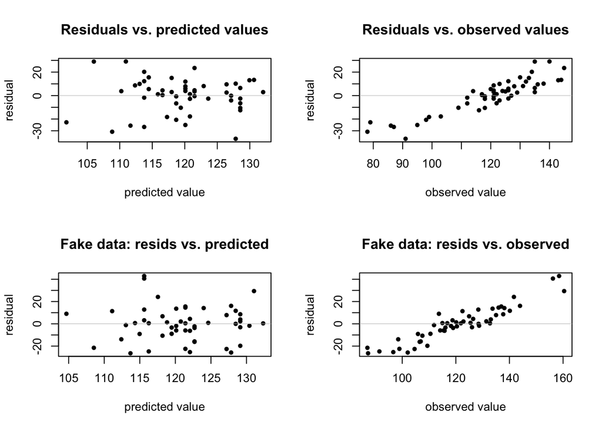

```r
## Construct fitted values

n <- length(final)
X <- cbind (rep(1,n), midterm)
predicted <- X %*% coef (lm.1)
resid <- lm.1$residuals

## Simulate fake data & compute fitted values

a <- 65
b <- 0.7
sigma <- 15
y.fake <- a + b*midterm + rnorm (n, 0, sigma)

lm.fake <- lm (y.fake ~ midterm)
predicted.fake <- X %*% coef (lm.fake)
resid.fake <- y.fake - predicted.fake

par (mfrow=c(2,2))

## Plots figure 8.1

 # plot on the left

plot (predicted, resid, xlab="predicted value", ylab="residual",
  main="Residuals vs. predicted values", pch=20)
abline (0,0, col="gray", lwd=.5)

 # plot on the right

plot (final, resid, xlab="observed value", ylab="residual",
  main="Residuals vs. observed values", pch=20)
abline (0,0, col="gray", lwd=.5)

## Plots figure 8.2

 # plot on the left

plot (predicted.fake, resid.fake, xlab="predicted value", ylab="residual",
  main="Fake data: resids vs. predicted", pch=20)
abline (0,0, col="gray", lwd=.5)

 # plot on the right

plot (y.fake, resid.fake, xlab="observed value", ylab="residual",
  main="Fake data: resids vs. observed", pch=20)
abline (0,0, col="gray", lwd=.5)
```

## III. Predictive simulation (20 - 30 min)

The key concept in predictive simulation for model checking is to **simulate from the fitted model and compare to the actual data**.

### Example 3: Comparing data to replications from a fitted

Data from Newcomb’s famous 1882 experiment to measure the speed of light.

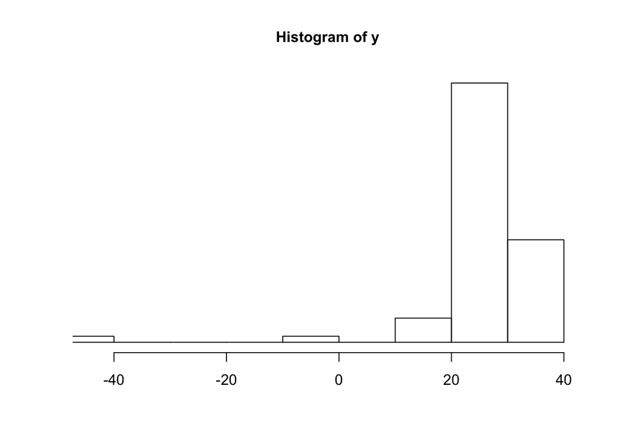

```r
## Read in the data
# Data are at http://www.stat.columbia.edu/~gelman/arm/examples/lightspeed
## library ("arm")

y <- scan(file.path(tmp_dir, "lightspeed.dat"), skip=4)

## Display original data
hist(y, xlab="", ylab="", cex.main="1", yaxt="n", xlim=range(y))
```

```r
## Model fit

light <- lm (y ~ 1)
display (light)
```

```
## lm(formula = y ~ 1)
##             coef.est coef.se
## (Intercept) 26.21     1.32
## ---
## n = 66, k = 1
## residual sd = 10.75, R-Squared = 0.00
```

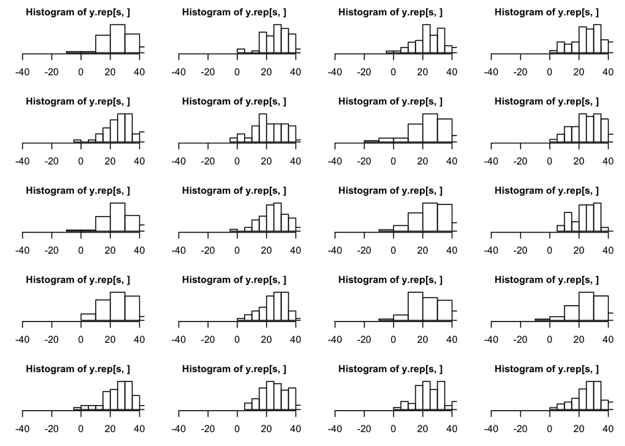

```r
## Create the replicated data

n.sims <- 1000
sim.light <- sim (light, n.sims)

## Create fake data

n <- length (y)
y.rep <- array (NA, c(n.sims, n))
for (s in 1:n.sims){
  y.rep[s,] <- rnorm (n, sim.light@coef[s], sim.light@sigma[s])
}

## Histogram of replicated data (Figure 8.4)

par (mfrow=c(5,4), mar=c(3,1,2,1))
for (s in 1:20){
  hist (y.rep[s,], xlab="", ylab="", cex.main="1", yaxt="n", xlim=range(y))
}
```

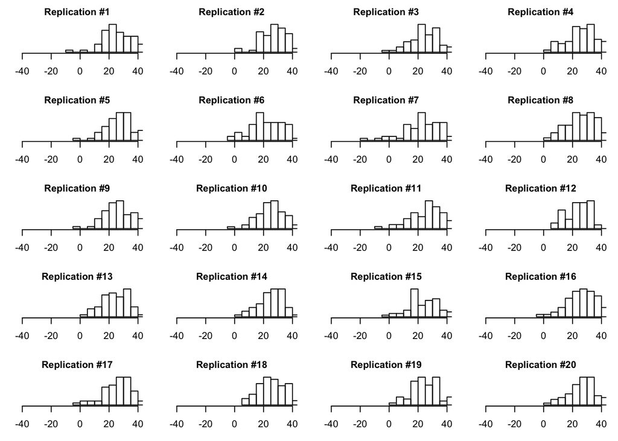

```r
## Write a function to make histograms with specified bin widths and ranges

Hist.preset <- function (a, width, ...){
  a.hi <- max (a, na.rm=TRUE)
  a.lo <- min (a, na.rm=TRUE)
  if (is.null(width)) width <- min (sqrt(a.hi-a.lo), 1e-5)
  bin.hi <- width*ceiling(a.hi/width)
  bin.lo <- width*floor(a.lo/width)
  hist (a, breaks=seq(bin.lo,bin.hi,width), ...)
}

## Run the function

par (mfrow=c(5,4), mar=c(3,1,2,1))
for (s in 1:20){
  Hist.preset (y.rep[s,], width=5, xlab="", ylab="", cex.main="1", yaxt="n",
               xlim=range(y), main=paste("Replication #",s,sep=""))
}
```

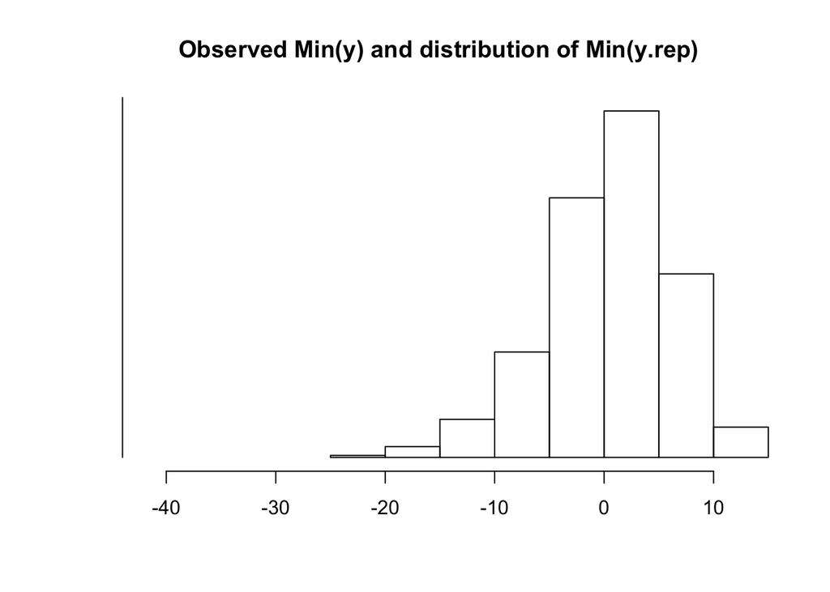

```r
## Numerical test

Test <- function (y){
  min (y)
}
test.rep <- rep (NA, n.sims)
for (s in 1:n.sims){
  test.rep[s] <- Test (y.rep[s,])
}

## Histogram Figure 8.5

par (mfrow=c(1,1))
hist (test.rep, xlim=range (Test(y), test.rep), yaxt="n", ylab="",
 xlab="", main="Observed Min(y) and distribution of Min(y.rep)")
lines (rep (Test(y), 2), c(0,10*n))
```

### Example 4: roaches

```r
##############################################################################
## Read the cleaned data
# All data are at http://www.stat.columbia.edu/~gelman/arm/examples/roaches
## library ("arm")

roachdata <- read.csv (file.path(tmp_dir, "roachdata.csv"))

library(R2OpenBUGS)
R2OpenBUGS::attach.all(roachdata)
```

```
## The following objects in .GlobalEnv will mask
## objects in the attached database:
## X, y
## Remove these objects from .GlobalEnv?
##
## 1: YES
## 2: NO
```

```r
## Note: attaching is dangerous and generally not recommended
## Except when you'd like the code to be highly readable.

head(roachdata)
```

```
##   X   y roach1 treatment senior exposure2
## 1 1 153 308.00         1      0  0.800000
## 2 2 127 331.25         1      0  0.600000
## 3 3   7   1.67         1      0  1.000000
## 4 4   7   3.00         1      0  1.000000
## 5 5   0   2.00         1      0  1.142857
## 6 6   0   0.00         1      0  1.000000
```

```r
## Fit the model
```

```r
glm.1 <- glm(y ~ roach1 + treatment + senior, family=poisson,
  offset=log(exposure2))
display (glm.1)
```

```
## glm(formula = y ~ roach1 + treatment + senior, family = poisson,
##     offset = log(exposure2))
##             coef.est coef.se
## (Intercept)  3.09     0.02
## roach1       0.01     0.00
## treatment   -0.52     0.02
## senior      -0.38     0.03
## ---
##   n = 262, k = 4
##   residual deviance = 11429.5, null deviance = 16953.7 (difference = 5524.2)
```

```r
## Comparing the data to a replicated dataset

n <- length(y)
X <- cbind (rep(1,n), roach1, treatment, senior)
y.hat <- exposure2 * exp (X %*% coef(glm.1))
y.rep <- rpois (n, y.hat)

print (mean (y==0))
```

```
## [1] 0.3587786
```

```r
print (mean (y.rep==0))
```

```
## [1] 0
```

```r
## Comparing the data to 1000 replicated datasets

n.sims <- 1000
sim.1 <- sim (glm.1, n.sims)
y.rep <- array (NA, c(n.sims, n))
for (s in 1:n.sims){
  y.hat <- exposure2 * exp (X %*% sim.1@coef[s,])
  y.rep[s,] <- rpois (n, y.hat)
}

 # test statistic

Test <- function (y){
  mean (y==0)
}
test.rep <- rep (NA, n.sims)
for (s in 1:n.sims){
  test.rep[s] <- Test (y.rep[s,])
}

# p-value
print (mean (test.rep > Test(y)))
```

```
## [1] 0
```

Now let’s fit a overdispersed Poisson (negative binomial).

```r
## Checking the overdispersed model

glm.2 <- glm (y ~ roach1 + treatment + senior, family=quasipoisson,
  offset=log(exposure2))
display (glm.2)
```

```
## glm(formula = y ~ roach1 + treatment + senior, family = quasipoisson,
##     offset = log(exposure2))
##             coef.est coef.se
## (Intercept)  3.09     0.17
## roach1       0.01     0.00
## treatment   -0.52     0.20
## senior      -0.38     0.27
## ---
##   n = 262, k = 4
##   residual deviance = 11429.5, null deviance = 16953.7 (difference = 5524.2)
##   overdispersion parameter = 65.4
```

```r
 # 1000 replicated datasets

n.sims <- 1000
sim.2 <- sim (glm.2, n.sims)
y.rep <- array (NA, c(n.sims, n))
overdisp <- summary(glm.2)$dispersion
for (s in 1:n.sims){
  y.hat <- exposure2 * exp (X %*% sim.2@coef[s,])
  a <- y.hat/(overdisp-1)              # using R's parametrization for the
  y.rep[s,] <- rnegbin (n, y.hat, a)   # negative binomial distribution
}

test.rep <- rep (NA, n.sims)
for (s in 1:n.sims){
  test.rep[s] <- Test (y.rep[s,])
}

# p-value
print (mean (test.rep > Test(y)))
```

```
## [1] 0.199
```

### Example 5: Check the fit of a time-series model

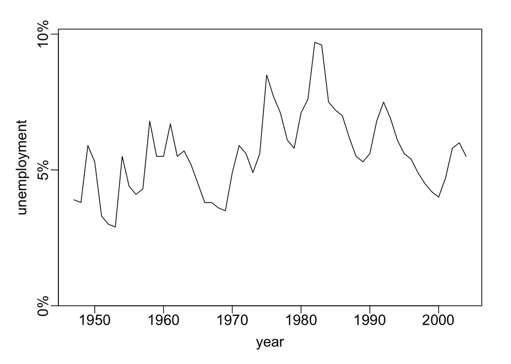

```r
## Read in the data
# Data are at http://www.stat.columbia.edu/~gelman/arm/examples/unemployment
## library ("arm")

unemployment <- read.table (file.path(tmp_dir, "unemployment.dat"), header=TRUE)
year <- unemployment$year
y <- unemployment$unemployed.pct

## Plot of the unemployment rate

par (mar=c(4,4,2,2))
plot (year, y, type="l", ylab="unemployment", xlab="year", yaxs="i",
  ylim=c(0, max(y)*1.05), yaxt="n", mgp=c(2,.5,0), cex.axis=1.2, cex.lab=1.2)
axis (2, c(0,5,10), paste (c(0,5,10), "%", sep=""), mgp=c(2,.5,0), cex.axis=1.2)
```

```r
## Fitting a 1st-order autogregression

n <- length (y)
y.lag <- c (NA, y[1:(n-1)])
lm.lag <- lm (y ~ y.lag)
display (lm.lag)
```

```
## lm(formula = y ~ y.lag)
##             coef.est coef.se
## (Intercept) 1.43     0.50
## y.lag       0.75     0.09
## ---
## n = 57, k = 2
## residual sd = 0.99, R-Squared = 0.57
```

```r
## Simulating replicated datasets

b.hat <- coef (lm.lag)        # vector of 2 regression coefs
s.hat <- sigma.hat (lm.lag)   # residual sd

n.sims <- 1000
y.rep <- array (NA, c(n.sims, n))
for (s in 1:n.sims){
  y.rep[s,1] <- y[1]
  for (t in 2:n){
    prediction <- c (1, y.rep[s,t-1]) %*% b.hat
    y.rep[s,t] <- rnorm (1, prediction, s.hat)
  }
}

## Including uncertainty in the estimated parameters

lm.lag.sim <- sim (lm.lag, n.sims)       # simulations of beta and sigma
for (s in 1:n.sims){
  y.rep[s,1] <- y[1]
  for (t in 2:n){
    prediction <-  c (1, y.rep[s,t-1]) %*% lm.lag.sim@coef[s,]
    y.rep[s,t] <- rnorm (1, prediction, lm.lag.sim@sigma[s])
  }
}
```

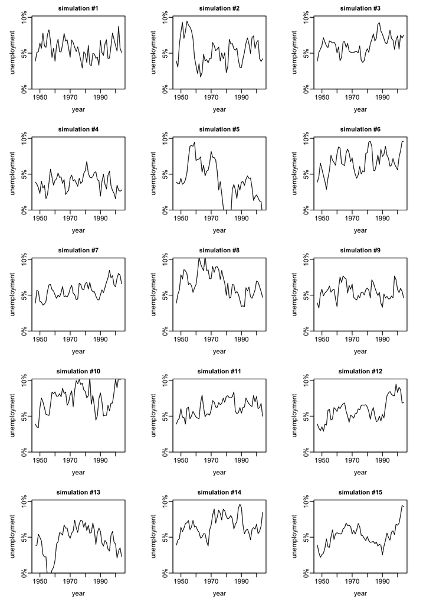

```r
## Plot of simulated unemployment rate series

par (mfrow=c(5,3), mar=c(4,4,2,2))
for (s in 1:15){
  plot (year, y.rep[s,], type="l", ylab="unemployment", xlab="year", yaxs="i",
  ylim=c(0, max(y)*1.05), yaxt="n", mgp=c(2,.5,0),
        main=paste("simulation #", s, sep=""), cex.main=0.95)
  axis (2, c(0,5,10), paste (c(0,5,10), "%", sep=""), mgp=c(2,.5,0))
}
```

```r
## Numerical model check

Test <- function (y){
  n <- length (y)
  y.lag <- c (NA, y[1:(n-1)])
  y.lag2 <- c (NA, NA, y[1:(n-2)])
  sum (sign(y-y.lag) != sign(y.lag-y.lag2), na.rm=TRUE)
}

n.sims <- 1000
print (Test (y))
```

```
## [1] 23
```

```r
test.rep <- rep (NA, n.sims)
for (s in 1:n.sims){
  test.rep[s] <- Test (y.rep[s,])
}

print (mean (test.rep > Test(y)))
```

```
## [1] 0.96
```

```r
print (quantile (test.rep, c(.05,.5,.95)))
```

```
##  5% 50% 95%
##  24  30  36
```

## IV. Closing activity (5 - 10 min)

### Think-pair-share

1. Think: Where/how you could apply today’s concepts and skills to one of your data analytic problems.
2. Pair: Refine your thoughts through discussion with a partner or small-group near you.
3. Share: Share your combined thoughts with the whole group.

### Thanks for your attention and participation!

Let me know if you have any questions.